# Molecular Orbitals and the LCAO Method

Author

Daniel Fischer

# Introduction

Molecular orbitals (MOs) provide a framework for understanding **how atoms combine to form molecules**, influencing chemical bonding, spectroscopy, and reactivity. The **Linear Combination of Atomic Orbitals (LCAO)** method offers a simple and intuitive way to construct MOs by combining atomic orbitals (AOs) from individual atoms.

The H$_2^+$ molecular ion—consisting of a single electron in the field of two protons—is the simplest molecule to study. Despite its simplicity, it illustrates key concepts of bonding, symmetry, and energy splitting, making it an ideal example for introducing the LCAO method.

### Goals of this Chapter

By the end of this chapter, you should be able to:

1. Explain the **LCAO method** and how it transforms the Schrödinger equation into a solvable matrix problem.
2. Distinguish **bonding** and **antibonding** molecular orbitals and relate them to constructive and destructive interference of atomic orbitals.
3. Understand the role of **symmetry** ($\sigma$, $\pi$, $\delta$; g/u labels) in classifying molecular orbitals.
4. Analyze the H$_2^+$ molecular ion as a concrete example, including **1D wavefunctions, electron density, and potential energy curves**.
5. Appreciate the **limitations of the simplest LCAO approximation** and how electron density distribution determines bonding strength.

This chapter combines **analytical derivations, graphical visualizations, and qualitative reasoning** to build both conceptual and practical understanding of molecular orbitals.

# 1. Conceptual Overview of the Linear Combination of Atomic Orbitals (LCAO)

The central idea of the **Linear Combination of Atomic Orbitals (LCAO)** method is that molecular orbitals can be expressed as a linear combination of atomic orbitals from the constituent atoms. For a diatomic molecule, for instance, we might write

$$\Phi = c_A \phi_A + c_B \phi_B,$$

where $\phi_A$ and $\phi_B$ are atomic orbitals centered on nuclei $A$ and $B$, and $c_A$, $c_B$ are the corresponding coefficients.

The idea is simple but powerful: we assume that the true molecular wavefunction can be represented as a combination of known basis functions. This transforms the Schrödinger equation from a complicated differential equation into a **set of algebraic equations** for the coefficients $c_A$, $c_B$, etc.

## 1.1 From the Variational Principle to the Secular Equation

You have already encountered the **Ritz variational principle**, which states that the best approximate energy within a chosen trial space minimizes the expectation value of the Hamiltonian:

$$E = \frac{\langle \Phi | \hat{H} | \Phi \rangle}{\langle \Phi | \Phi \rangle}.$$

If we substitute our LCAO form of $\Phi$ and take partial derivatives with respect to the coefficients, we obtain a set of linear equations:

$$\sum_j (H_{ij} - E S_{ij}) c_j = 0,$$

where

- $H_{ij} = \langle \phi_i | \hat{H} | \phi_j \rangle$ are **Hamiltonian matrix elements**,
- $S_{ij} = \langle \phi_i | \phi_j \rangle$ are **overlap integrals**, and
- $c_j$ are the coefficients to be determined.

This is called the **secular equation**.  
In matrix form, it can be written compactly as

$$\mathbf{H} \vec{c} = E\, \mathbf{S} \vec{c}.$$

This is a **generalized eigenvalue problem**.  
For each eigenvalue $E_n$, there is a corresponding eigenvector $\vec{c}_n$ that gives the coefficients of the $n$-th molecular orbital.

**Note**

In practice, solving the secular (or Roothaan) equations is just solving a set of coupled linear equations for the coefficients $c_j$. This is why matrix methods play such a central role in modern quantum chemistry.

# 2. The H$_2^+$ Molecular Ion

The H$_2^+$ ion is the simplest possible molecule: two protons and one electron.  
This one-electron system is ideal to study bonding from first principles.

## 2.1 Atomic Orbitals

For each hydrogen nucleus, we use the 1s atomic orbital:

$$\phi_A(\vec{r}_A) = \frac{1}{\sqrt{\pi a_0^3}} e^{-r_A / a_0}, \quad
\phi_B(\vec{r}_B) = \frac{1}{\sqrt{\pi a_0^3}} e^{-r_B / a_0}$$

The total molecular orbital is written as a superposition:

$$\Phi(\vec{r}) = c_1 \phi_A(\vec{r}_A) + c_2 \phi_B(\vec{r}_B)$$

with $\vec{r}_A = \vec{r} + \frac{\vec{R}}{2}$ and $\vec{r}_B = \vec{r} - \frac{\vec{R}}{2}$, where $\vec{R}$ is the internuclear vector.

## 2.2 Normalization

The normalization condition reads:

$$\langle \Phi | \Phi \rangle = c_1^2 + c_2^2 + 2\,\mathrm{Re}\!\left(c_1^* c_2\, S_{AB}\right) = 1$$

where $S_{AB} = \langle \phi_A | \phi_B \rangle$ is the overlap integral.

In most diatomic systems, however, the atomic orbitals can be chosen to be **real**. In that case, the expression simplifies to:

$$c_1^2 + c_2^2 + 2 c_1 c_2 S_{AB} = 1$$

This normalization guarantees that the total molecular orbital $\Phi$ represents a physically valid wavefunction with unit probability.

Because the H$_2^+$ system is symmetric, $|c_1| = |c_2|$, and the normalized symmetric and antisymmetric molecular orbitals are:

$$|\Phi_g\rangle = \frac{1}{\sqrt{2 + 2S_{AB}}} (|\phi_A\rangle + |\phi_B\rangle)$$

$$|\Phi_u\rangle = \frac{1}{\sqrt{2 - 2S_{AB}}} (|\phi_A\rangle - |\phi_B\rangle)$$

The subscripts $g$ (gerade) and $u$ (ungerade) refer to **inversion symmetry**:  
- $\Phi_g$ is symmetric (even) under inversion through the midpoint  
- $\Phi_u$ is antisymmetric (odd)

The figure shows one-dimensional slices through the molecular orbitals of H$_2^+$ along the internuclear axis. The two vertical dashed lines mark the positions of the nuclei A and B.

The blue curves correspond to the **antibonding** (antisymmetric or ungerade) combination of $1s$ wave functions:  
- The solid blue line shows $|\Phi_u|^2$, which has a node (zero probability density) midway between the nuclei.  
- The dotted blue line shows $\Phi_u$, which changes sign at the midpoint (destructive interference).

This visual comparison highlights how constructive overlap in the bonding orbital increases electron density between the nuclei—leading to attraction and molecular stability—whereas destructive overlap in the antibonding orbital produces a node and repulsion.

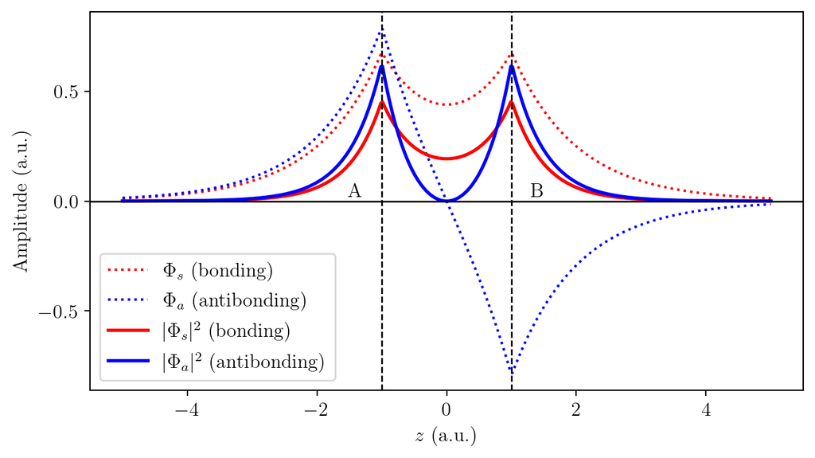

```python
import numpy as np
import matplotlib.pyplot as plt
plt.rcParams['text.usetex'] = True
plt.rcParams['font.family'] = 'serif'
plt.rcParams['font.size'] = 12

# parameters (atomic units)
a0 = 1.0
R = 2.0  # internuclear separation in Bohr radii
x = np.linspace(-5, 5, 400)

# hydrogenic 1s orbital centered at ±R/2
phi_A = np.exp(-np.abs(x + R/2) / a0)
phi_B = np.exp(-np.abs(x - R/2) / a0)

# normalize atomic orbitals (1D projection)
phi_A /= np.sqrt(np.trapezoid(phi_A**2, x))
phi_B /= np.sqrt(np.trapezoid(phi_B**2, x))

# bonding (sigma_g) and antibonding (sigma_u) combinations
# Need to normalize these properly including overlap
overlap = np.trapezoid(phi_A * phi_B, x)
N_g = 1.0 / np.sqrt(2 * (1 + overlap))  # normalization for bonding
N_u = 1.0 / np.sqrt(2 * (1 - overlap))  # normalization for antibonding

phi_g = N_g * (phi_A + phi_B)
phi_u = N_u * (phi_A - phi_B)

# verify normalization
# print(f"Overlap integral: {overlap:.4f}")
# print(f"Norm of phi_g: {np.trapezoid(phi_g**2, x):.4f}")
# print(f"Norm of phi_u: {np.trapezoid(phi_u**2, x):.4f}")

# probability densities
rho_g = phi_g**2
rho_u = phi_u**2

y_ticks = [-0.5, 0, 0.5, 1.0, 1.5]
plt.figure(figsize=(7,4))
plt.yticks(y_ticks)
plt.plot(x, phi_g, label=r'$\Phi_s$ (bonding)', lw=1.5, ls=':', color='r')
plt.plot(x, phi_u, label=r'$\Phi_a$ (antibonding)', lw=1.5, ls=':', color='b')
plt.plot(x, rho_g, label=r'$|\Phi_s|^2$ (bonding)', lw=2, color='r')
plt.plot(x, rho_u, label=r'$|\Phi_a|^2$ (antibonding)', lw=2, color='b')
plt.axvline(-R/2, color='k', ls='--', lw=1)
plt.axvline(R/2, color='k', ls='--', lw=1)
plt.axhline(0, color='k', lw=1)
plt.text(-R/2-0.3, 0.02, 'A', ha='right', fontsize=12)
plt.text(R/2+0.3, 0.02, 'B', ha='left', fontsize=12)
plt.xlabel('$z$  (a.u.)')
plt.ylabel('Amplitude (a.u.)')
plt.legend()
plt.tight_layout()
plt.show()
```

## 2.3 Energies

The energies of these molecular orbitals are:

$$E_g(R) = \frac{H_{AA} + H_{AB}}{1 + S_{AB}}, \qquad
E_u(R) = \frac{H_{AA} - H_{AB}}{1 - S_{AB}}$$

with:
$$H_{AA} = \langle \phi_A | \hat{H} | \phi_A \rangle, \quad
H_{AB} = \langle \phi_A | \hat{H} | \phi_B \rangle$$

Typically, $H_{AB} < 0$, so $E_g < E_u$. The symmetric (gerade) combination therefore has lower energy — it is a **bonding orbital**.

**NoteQuick check: Plugging in the normalized $\Phi_g$ and $\Phi_u$ to get $E_g$ and $E_u$**

We start from the normalized symmetric and antisymmetric molecular orbitals

$$\Phi_g=\frac{\phi_A+\phi_B}{\sqrt{2+2S}},\qquad
\Phi_u=\frac{\phi_A-\phi_B}{\sqrt{2-2S}},$$

with $S\equiv S_{AB}=\langle\phi_A|\phi_B\rangle$.  
Assume identical centres so that $H_{AA}=H_{BB}$ and $H_{AB}=H_{BA}$, where $H_{ij}=\langle\phi_i|\hat H|\phi_j\rangle$.

### Bonding (symmetric) case

Compute the expectation value

$$\langle\Phi_g|\hat H|\Phi_g\rangle
= \frac{\langle\phi_A+\phi_B|\hat H|\phi_A+\phi_B\rangle}{2+2S}.$$

Expand the numerator:

$$\begin{aligned}
\langle\phi_A+\phi_B|\hat H|\phi_A+\phi_B\rangle
&= \langle\phi_A|\hat H|\phi_A\rangle
+ \langle\phi_A|\hat H|\phi_B\rangle \\
&\quad + \langle\phi_B|\hat H|\phi_A\rangle
+ \langle\phi_B|\hat H|\phi_B\rangle \\
&= H_{AA} + H_{AB} + H_{AB} + H_{AA} \\
&= 2H_{AA} + 2H_{AB}.
\end{aligned}$$

Therefore

$$E_g(R)=\frac{\langle\Phi_g|\hat H|\Phi_g\rangle}{\langle\Phi_g|\Phi_g\rangle}
= \frac{2H_{AA}+2H_{AB}}{2+2S}
= \frac{H_{AA}+H_{AB}}{1+S}.$$